# project1C5

sourabh jain

04/06/2020

# Project 1

## Intructions for the assignment

1.Code for reading in the dataset and/or processing the data  
2.Histogram of the total number of steps taken each day  
3.Mean and median number of steps taken each day  
4.Time series plot of the average number of steps taken  
5.The 5-minute interval that, on average, contains the maximum number of steps  
6.Code to describe and show a strategy for imputing missing data  
7.Histogram of the total number of steps taken each day after missing values are imputed  
8.Panel plot comparing the average number of steps taken per 5-minute interval across weekdays and weekends  
9.All of the R code needed to reproduce the results (numbers, plots, etc.) in the report

### 1.Code for reading in the dataset and/or processing the data

```r
setwd("C:/Users/Srb/Documents/Sourabh")
activity<-read.csv("activity.csv")
```

#### Exploring data

```r
dim(activity)
```

```
## [1] 17568     3
```

```r
str(activity)
```

```
## 'data.frame':    17568 obs. of  3 variables:
##  $ steps   : int  NA NA NA NA NA NA NA NA NA NA ...
##  $ date    : Factor w/ 61 levels "2012-10-01","2012-10-02",..: 1 1 1 1 1 1 1 1 1 1 ...
##  $ interval: int  0 5 10 15 20 25 30 35 40 45 ...
```

```r
names(activity)
```

```
## [1] "steps"    "date"     "interval"
```

```r
head(activity)
```

```
##   steps       date interval
## 1    NA 2012-10-01        0
## 2    NA 2012-10-01        5
## 3    NA 2012-10-01       10
## 4    NA 2012-10-01       15
## 5    NA 2012-10-01       20
## 6    NA 2012-10-01       25
```

```r
sum(is.na(activity))
```

```
## [1] 2304
```

```r
# with lubridate package change the date formate
library(lubridate)
activity$date<-ymd(activity$date)
length(unique(activity$date))
```

```
## [1] 61
```

### 2. Histogram of the total number of steps taken each day

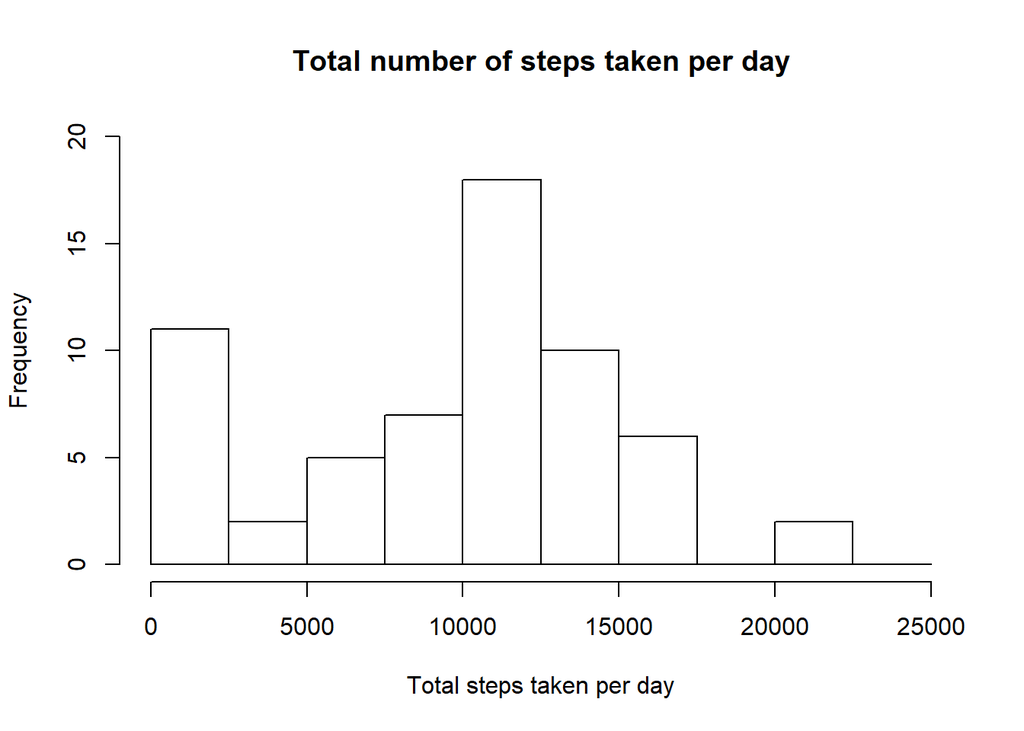

```r
total_steps <- with(activity, aggregate(steps, by = list(date), FUN = sum, na.rm = TRUE))
names(total_steps) <- c("date", "steps")
hist(total_steps$steps, main = "Total number of steps taken per day", xlab = "Total steps taken per day", ylim = c(0,20), breaks = seq(0,25000, by=2500))
```

### 3. Mean and median number of steps taken each day

```r
mean(total_steps$steps)
```

```
## [1] 9354.23
```

```r
median(total_steps$steps)
```

```
## [1] 10395
```

### 4.Time series plot of the average number of steps taken

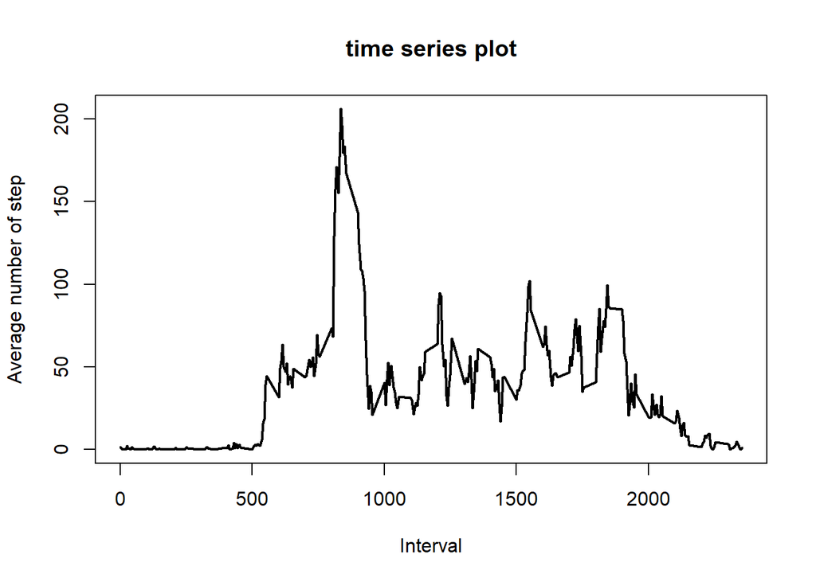

```r
average_activity<-with(activity, aggregate(steps, by=list(interval), FUN= mean,na.rm=TRUE))
names(average_activity)<-c("interval","avg_step")
plot(average_activity$interval,average_activity$avg_step, type="l", xlab="Interval", ylab="Average number of step", lwd=2, main="time series plot")
```

### 5. The 5-minute interval that, on average, contains the maximum number of steps

```r
average_activity[which.max(average_activity$avg_step),1]
```

```
## [1] 835
```

### 6. Histogram of the total number of steps taken each day after missing values are imputed

I decided to fill in all of the missing values in the dataset by the mean number of steps per interval.

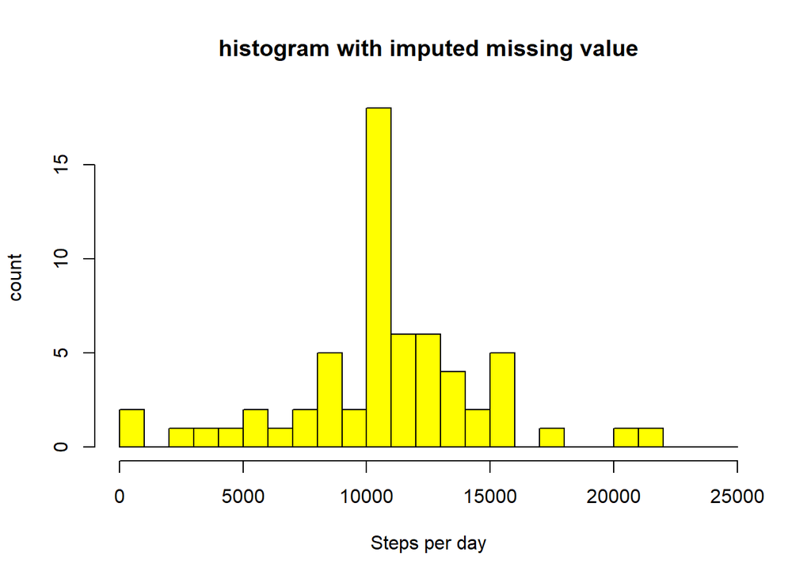

```r
m<-mean(average_activity$avg_step)
missingIndex<-is.na(activity[,1])
activity1<-activity
activity1[missingIndex,1]<-m
total_steps_imputed<-with(activity1, aggregate(steps, by=list(date), FUN=sum))
names(total_steps_imputed)<-c("date","step")
hist(total_steps_imputed$step, xlab="Steps per day", ylab="count",main = "histogram with imputed missing value", col="yellow", breaks = seq(0,25000,by=1000))
```